# Week 12: Metropolis and Metropolis–Hastings

STAT 536 — Statistical Computing

Soumojit Das

Fall 2026

# Metropolis in Practice

## Where We Are

- Last week: for an irreducible Markov chain with stationary distribution $\pi$ and $\E_\pi[|h(X)|] < \infty$, $\bar h_N \to \E_\pi[h(X)]$ with probability one.
- Its accuracy, for a geometrically ergodic chain with $\E_\pi[|h(X)|^{2+\eta}] < \infty$: Monte Carlo standard error $\sigma_h/\sqrt{\text{ESS}}$, with $\text{ESS} = N/\kappa$.
- The backward problem: start from $\pi$, known up to a constant, and construct a chain that has $\pi$ as its stationary distribution. Detailed balance is the tool: Metropolis satisfies it for any symmetric proposal.
- This week: Metropolis on targets whose answers we know, and what the proposal scale does to the ESS.
- Then Metropolis–Hastings: the same construction for any proposal, with a correction that restores detailed balance.

where $\pi$: the target density; $\bar h_N = \frac1N\sum_{t=1}^N h(X_t)$: the time average over a chain of length $N$; $\sigma_h^2 = \Var_\pi(h(X))$; $\kappa = 1 + 2\sum_{k \ge 1}\rho_k$, with $\rho_k$ the autocorrelation at lag $k$; $\eta$: a positive number; ESS: the effective sample size.

## The Metropolis Algorithm

**The Metropolis Algorithm**

Target $\pi$, known up to a constant. Symmetric proposal $q(y \mid x) = q(x \mid y)$. Start $X_0$ with $\pi(X_0) > 0$. For $t = 0, 1, 2, \ldots$:

1. Draw $Y \sim q(\cdot \mid X_t)$.
2. Compute $\alpha(X_t, Y) = \min\bigl(1, \pi(Y)/\pi(X_t)\bigr)$.
3. Draw $U \sim \Uniform(0, 1)$.
4. Set $X_{t+1} = Y$ if $U \le \alpha(X_t, Y)$, otherwise $X_{t+1} = X_t$.
- Transition density $K(x, y) = q(y \mid x)\,\alpha(x, y)$ for $y \ne x$; rejection probability $r_{\text{rej}}(x) = 1 - \int q(y \mid x)\,\alpha(x, y)\,dy$.
- Theorem: this chain satisfies detailed balance with respect to $\pi$, and $\pi$ is stationary.
- Propose a move; take it with probability $\alpha$; otherwise record the current state again.

where $\pi$: the target density; $q(y \mid x)$: the proposal density from $x$ to $y$; $X_t$: the state at time $t$; $Y$: the proposed value; $\alpha$: the acceptance probability; $U$: a uniform draw.

## Understanding the Acceptance Probability

$$\alpha(x, y) = \min\left(1, \frac{\pi(y)}{\pi(x)}\right)$$

- If $\pi(y) \ge \pi(x)$: always accept, a move to higher density.
- If $\pi(y) < \pi(x)$: sometimes accept, with probability equal to the ratio.
- We prefer moves to higher density, but occasionally accept moves to lower density: this lets the chain move away from a mode.
- We only need the ratio $\pi(y)/\pi(x)$: if $\pi(x) = c\,\tilde\pi(x)$ with unknown $c$, the $c$ cancels.

where $\alpha(x, y)$: the acceptance probability; $x$: the current state; $y$: the proposed value; $\pi$: the target density; $\tilde\pi$: the target up to the constant $c$.

## Example: $\Betad(3, 2)$

- **Target:** $\Betad(3, 2)$ on $(0, 1)$: $\pi(\theta) \propto \theta^{2}(1-\theta)$.
- **Proposal:** a random walk on $(0, 1)$ with half-width $\ell = 0.2$:
  $$\theta^* = \theta^{(t)} + Z, \quad Z \sim \Uniform(-\ell, \ell)$$
- The density of a move is $1/(2\ell)$ whenever $|\theta^* - \theta^{(t)}| < \ell$: the proposal is symmetric.
- If $\theta^* \notin (0, 1)$, reject immediately: $\pi(\theta^*) = 0$.
- **Acceptance probability:**
  $$\alpha(\theta^{(t)}, \theta^*) = \min\left(1, \frac{(\theta^*)^{2}(1-\theta^*)}{(\theta^{(t)})^{2}(1-\theta^{(t)})}\right)$$

where $\theta^{(t)}$: the state at time $t$; $\theta^*$: the proposed value; $Z$: the step; $\ell$: the half-width of the uniform proposal.

## Beta Example: Implementation

```r
log_pi <- function(theta) {                   # Beta(3, 2), up to a constant
  if (theta <= 0 || theta >= 1) return(-Inf)
  2 * log(theta) + log(1 - theta)
}
metropolis_beta <- function(n_iter, ell = 0.2, theta0 = 0.5) {
  theta <- numeric(n_iter); theta[1] <- theta0; n_accept <- 0
  for (t in 2:n_iter) {
    theta_star <- theta[t - 1] + runif(1, -ell, ell)
    log_alpha <- log_pi(theta_star) - log_pi(theta[t - 1])
    if (runif(1) < min(1, exp(log_alpha))) {
      theta[t] <- theta_star; n_accept <- n_accept + 1
    } else theta[t] <- theta[t - 1]
  }
  list(theta = theta, accept_rate = n_accept / n_iter)
}
```

where `ell`: the half-width $\ell$ of the uniform proposal; `theta0`: the start; `n_iter`: the chain length $N$; `theta_star`: the proposed value $\theta^*$.

## Beta Example: Results

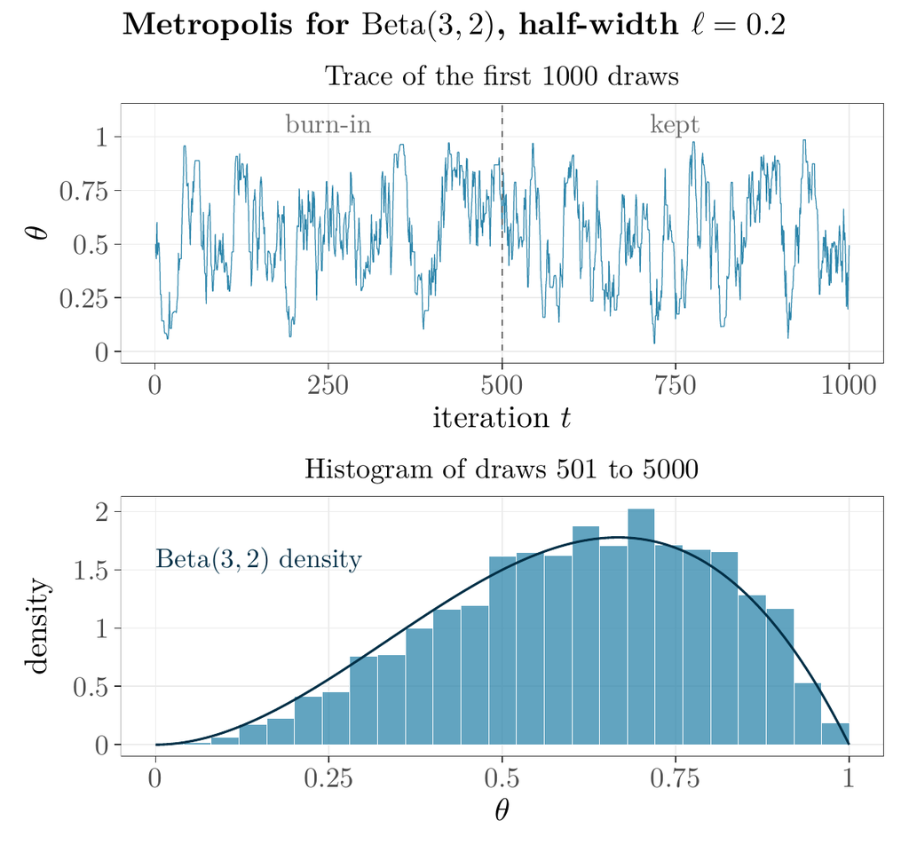

- Trace: the first 1000 draws; dashed line: the end of burn-in, iteration 500.
- Histogram: draws 501 to 5000; dark curve: the $\Betad(3, 2)$ density.
- Acceptance rate 0.82; ESS about 325 of 4,500 kept draws; mean 0.613, Monte Carlo standard error 0.011, against the exact 0.600.
- The 4,500 draws are dependent: they carry the information of about 325 independent ones.

where $\theta$: the state of the chain; $\ell$: the half-width of the uniform proposal; ESS: the effective sample size, from `coda::effectiveSize()`.

## What the Chain Did

- Initialized at $\theta^{(0)} = 0.5$.
- Proposed moves via a random walk.
- Always accepted moves to higher density.
- Sometimes accepted moves to lower density.
- The first 500 iterations are discarded as burn-in.

The histogram matches the $\Betad(3, 2)$ density.

We sampled from $\Betad(3, 2)$ using only the unnormalized density $\theta^2(1-\theta)$.

## Example: A Gamma Posterior

- **Data:** 50 counts simulated from $\Pois(5)$: 4, 4, 8, 6, 2, 3, 6, 4, 0, 5, 4, 6, 2, 5, 4, 5, 3, 3, 1, 2, 4, 7, 4, 6, 4, 3, 1, 4, 3, 3, 5, 4, 5, 2, 3, 2, 5, 8, 9, 8, 2, 2, 5, 7, 4, 3, 6, 7, 5, 9. Here $\sum_i x_i = 217$ and $\bar x = 4.34$, below the rate 5 that generated them.
- **Model and prior:** $X_1, \ldots, X_n \mid \lambda \iid \Pois(\lambda)$, $n = 50$; $\lambda \sim \Gam(2, 0.5)$.
- **Posterior:** $\lambda \mid \mathbf{x} \sim \Gam\bigl(2 + \sum_i x_i,\ 0.5 + n\bigr) = \Gam(219, 50.5)$, with mean 4.337 and standard deviation 0.293.
- Likelihood times prior, the unnormalized posterior that Metropolis samples from:
  $$\pi(\lambda \mid \mathbf{x}) \propto \prod_{i=1}^n \lambda^{x_i}e^{-\lambda} \times \lambda^{2-1}e^{-0.5\lambda} = \lambda^{218}e^{-50.5\lambda}, \quad \lambda > 0$$
- **Proposal:** a random walk, $\lambda^* = \lambda^{(t)} + Z$, $Z \sim \Normal(0, s^2)$, from $\lambda^{(0)} = 5$. A $\lambda^* \le 0$ has posterior density 0 and is rejected.

where $\lambda$: the Poisson rate; $\mathbf{x} = (x_1, \ldots, x_n)$: the observed counts; $\bar x$: their mean; $\Gam(a, b)$: shape $a$, rate $b$; $\lambda^{(t)}$: the state at time $t$; $\lambda^*$: the proposed value; $s$: the standard deviation of the step $Z$.

## Proposal Scale and Dependence

- Recall $\text{ESS} = N/\kappa$, with $\kappa = 1 + 2\sum_{k \ge 1}\rho_k$: tuning aims at a large ESS, so at successive draws as close to independent as we can make them.
- A rejection repeats the value, $X_{t+1} = X_t$; an accepted proposal moves the chain by the step, $X_{t+1} = X_t + Z$.
- Once the chain is stationary, $X_t$ and $X_{t+1}$ both have law $\pi$, so $\E[X_{t+1}] = \E[X_t]$ and $\Var(X_{t+1}) = \Var(X_t) = \sigma^2$:
  $$\E\bigl[(X_{t+1} - X_t)^2\bigr] = \Var(X_{t+1} - X_t) = \Var(X_{t+1}) + \Var(X_t) - 2\Cov(X_t, X_{t+1}) = 2\sigma^2(1 - \rho_1)$$
- So $\rho_1 = 1 - \E\bigl[(X_{t+1} - X_t)^2\bigr]/(2\sigma^2)$: weak dependence needs moves that are both accepted and long.
- The scale $s$ trades one for the other. Small $s$: nearly every step accepted, each one short. Large $s$: long steps, nearly all rejected. Either way $\rho_1$ is near 1.

where $N$: the number of draws; $\kappa$: the inflation factor; $\rho_k$: the autocorrelation of $X_t$ at lag $k$; $X_t$: the state at time $t$; $Z \sim \Normal(0, s^2)$: the proposal step; $s$: its standard deviation; $\pi$: the target; $\sigma^2 = \Var_\pi(X)$.

## Acceptance Rate Diagnostics

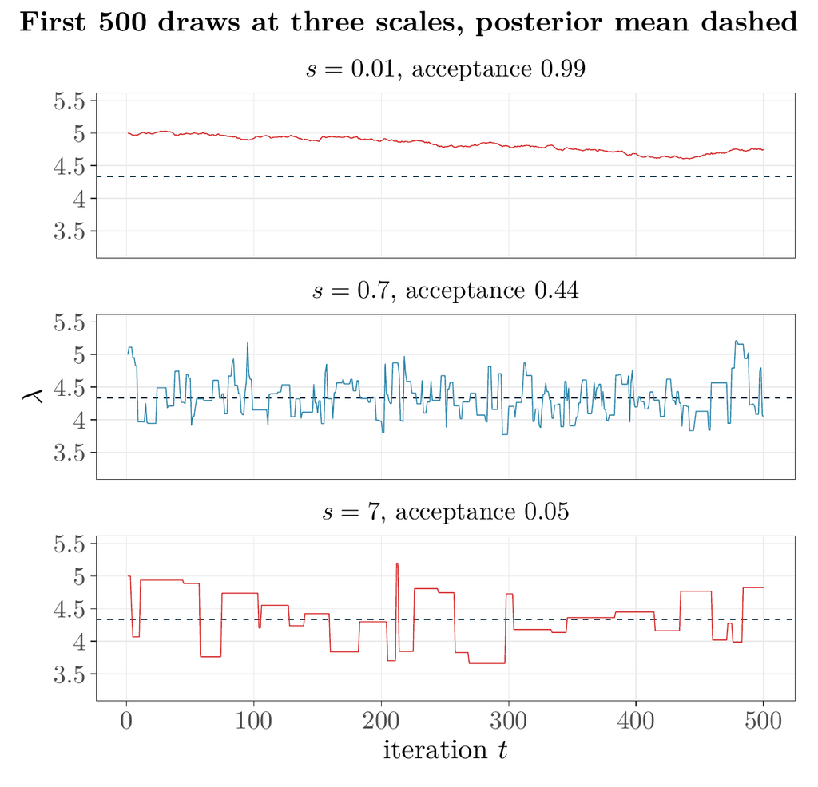

- Recall $\pi(\lambda \mid \mathbf{x}) \propto \lambda^{218}e^{-50.5\lambda}$: mean 4.337, SD 0.293.
- Top, $s = 0.01$: 99% accepted, but moves average 0.008: after 500 steps the chain is still above 4.6.
- Middle, $s = 0.7$: 44% accepted, moves average 0.29, one posterior SD: the chain crosses the posterior in a few steps.
- Bottom, $s = 7$: 5% accepted: each value is held 19 steps on average, the flat runs; 27% of proposals are negative.

where $\lambda^* = \lambda^{(t)} + Z$, $Z \sim \Normal(0, s^2)$: the proposal, from $\lambda^{(0)} = 5$; $\mathbf{x}$: the counts; dashed line: the posterior mean.

## Acceptance Rate and ESS

| Gamma posterior, 49,000 kept draws | $s = 0.01$ | $s = 0.7$ | $s = 7$ |
| --- | --- | --- | --- |
| acceptance rate | 0.99 | 0.44 | 0.05 |
| average $(X_{t+1} - X_t)^2$ | 0.000098 | 0.064 | 0.012 |
| lag-1 autocorrelation $\hat\rho_1$ | 0.9992 | 0.6263 | 0.9293 |
| ESS | 19 | 10,900 | 1,770 |
| AR(1) formula $N(1 - \hat\rho_1)/(1 + \hat\rho_1)$ | 19 | 11,300 | 1,790 |

- The highest acceptance rate gave the smallest ESS, as $\sigma = 0.1$ did in Lab 9: high acceptance is not the goal.
- Both ends leave $\hat\rho_1$ near 1: short moves at $s = 0.01$, rare moves at $s = 7$.
- Last row, Lab 9’s AR(1) formula with $\rho = \hat\rho_1$: within 4% of each ESS, so $\hat\rho_1$ nearly fixes the ESS.
- **The goal of tuning:** a large ESS, through weak dependence between successive draws.

where $s$: the SD of the proposal step; $X_t$: the state at time $t$; $\hat\rho_1$: the lag-1 autocorrelation; $N$: the kept draws; ESS: from `coda`, rough at $s = 0.01$; $\sigma$: Lab 9’s step SD.

## The 20–50% Rule of Thumb

- For **random walk Metropolis** with symmetric proposals, aim for an acceptance rate of 20–50%.
- $d = 1$: about 44%. $d = 2$ to 4: about 30–35%. $d \ge 5$: about 23–28%. These maximize ESS per step for a normal target and normal proposal (Gelman, Roberts, and Gilks, 1996).
- As $d \to \infty$ the optimum is 0.234, for independent, identically distributed coordinates and proposal scale $\propto 1/\sqrt{d}$ (Roberts, Gelman, and Gilks, 1997).
- The curve is flat near its peak: anywhere in 20–50%, ESS per step stays at about 60% or more of the best.
- In the Gamma example, $s = 0.7$ is about 2.4 times the posterior SD 0.293: the best scale for a normal target in $d = 1$, where the acceptance rate is about 44%.

where $d$: the dimension of the target; ESS: the effective sample size; $s$: the standard deviation of the proposal step.

## Connection to Accept-Reject

|  | Accept-Reject | Metropolis |
| --- | --- | --- |
| Proposals | independent | depend on the current state |
| Accept with probability | $\dfrac{f(y)}{Mg(y)}$ | $\min\left(1, \dfrac{\pi(y)}{\pi(x)}\right)$ |
| If rejected | the proposal is discarded | keep the current value |
| As $d$ grows | acceptance falls geometrically: $2^{-d/2}$ for target $\Normal(\mathbf{0}, \mathbf{I})$, proposal $\Normal(\mathbf{0}, 2\mathbf{I})$ | steps must shrink like $1/\sqrt{d}$ to keep acceptance away from 0, and ESS per step falls like $1/d$ (independent coordinates; Roberts, Gelman, and Gilks, 1997) |

- A rejection records the current state again: the repeated value is part of the sample from $\pi$.

where $f$, $g$, $M$: accept-reject’s target, sampling density, and bound, $f \le Mg$; $\pi$: the Metropolis target; $x$, $y$: the current and proposed values; $d$: the dimension; $\mathbf{0}$, $\mathbf{I}$: the zero vector and the identity matrix.

# Metropolis–Hastings

## Limits of the Random Walk

- Recall the Gamma posterior: at its best scale, $s = 0.7$, the random walk kept an ESS of 10,900 of 49,000 draws, with $\hat\rho_1 = 0.63$.
- A random walk proposes from $x$ alone: up and down alike, wherever $\pi$ has its mass.
- A step long enough to make $X_{t+1}$ nearly independent of $X_t$ usually lands where $\pi$ is small, and is rejected.
- Drawing from $\pi$ itself is the ideal: independent draws, $\text{ESS} = N$. A proposal close to $\pi$, the same wherever the chain is, can take long steps that are still accepted.
- **The point:** weaker dependence needs a proposal that aims at where $\pi$ has its mass, such as a draw from a guess $g$ of $\pi$ wherever the chain is. That proposal is not symmetric: $q(y \mid x) = g(y)$, $q(x \mid y) = g(x)$.

where $x$: the current value; $y$: the proposed value; $X_t$: the state at time $t$; $\pi$: the target; $s$: the standard deviation of the random-walk step; $\hat\rho_1$: the lag-1 autocorrelation of the kept draws; $N$: the number of draws; $q(y \mid x)$: the proposal density from $x$ to $y$; $g$: a density close to $\pi$.

## Reasons for Asymmetric Proposals

- Metropolis needs a symmetric proposal, $q(y \mid x) = q(x \mid y)$, such as the random walk $Y = x + Z$.
- **Using what we know about the target:** propose from a rough guess of $\pi$, the same wherever the chain is, as accept-reject did with $g$ in week 3: one accepted step can cross the whole posterior.
- **Staying in the support:** a random walk on a rate $\lambda > 0$ or a probability $p \in (0, 1)$ proposes values outside, each a wasted step, as the $\lambda^* \le 0$ at $s = 7$ and the $\theta^* \notin (0, 1)$ of the $\Betad(3, 2)$ chain were. Near a boundary, up to half the proposals land outside.
- A random walk on $\log x$, $\log Y = \log x + Z$, gives $Y = x\,e^{Z} > 0$; one on $\operatorname{logit} p$ stays in $(0, 1)$.
- Both fixes make the proposal asymmetric: $q(y \mid x) \ne q(x \mid y)$.

where $x$: the current value; $Y$, $y$: the proposed value; $Z$: a normal step; $q(y \mid x)$: the proposal density from $x$ to $y$; $\pi$: the target; $\lambda$: a rate; $p$: a probability; $\lambda^*$, $\theta^*$: the proposed values in the Gamma and $\Betad(3, 2)$ examples; $s$: the standard deviation of the Gamma random walk’s step; $g$: accept-reject’s sampling density; $\operatorname{logit} p = \log\bigl(p/(1 - p)\bigr)$.

## Random Walk and Independence Proposals

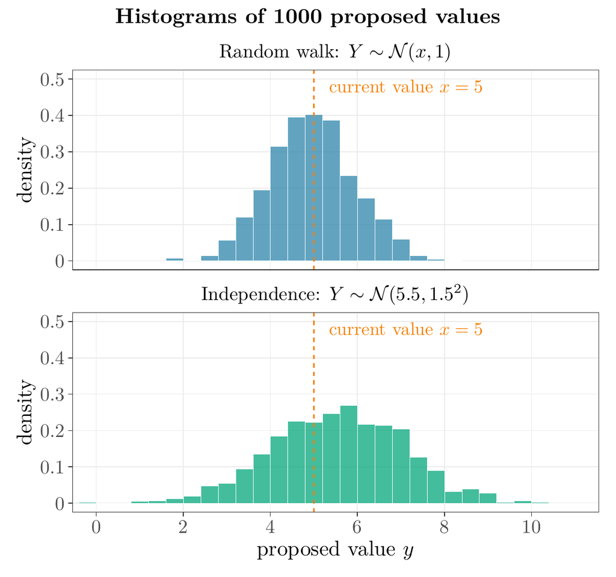

- Top: a random walk from the current value $x = 5$: symmetric, $q(y \mid x) = q(x \mid y)$.
- Bottom: an independence proposal, $\Normal(5.5, 1.5^2)$, the same density wherever the chain is: a rough guess of the target.
- The bottom proposal ignores $x$: $q(y \mid x) = q(y)$ and $q(x \mid y) = q(x)$, which differ unless $q(x) = q(y)$.

where $x$: the current value; $y$: the proposed value; $q(y \mid x)$: the proposal density from $x$ to $y$; $q(y)$: the independence proposal’s density.

## What Goes Wrong Without a Correction

- If we just use $\min\bigl(1, \pi(y)/\pi(x)\bigr)$ with an asymmetric proposal, detailed balance fails.
- Recall detailed balance from last week? With $K(x, y) = q(y \mid x)\,\alpha(x, y)$ it requires, for $y \ne x$,
  $$\pi(x)\,q(y \mid x)\,\alpha(x, y) = \pi(y)\,q(x \mid y)\,\alpha(y, x)$$
- Take $\pi(y) \ge \pi(x)$, so that $\alpha(x, y) = 1$ and $\alpha(y, x) = \pi(x)/\pi(y)$. The two sides are $\pi(x)\,q(y \mid x)$ and $\pi(x)\,q(x \mid y)$.
- When $q(y \mid x) \ne q(x \mid y)$, the symmetry we relied on is broken: the two flows differ.
- On two states, stationarity is detailed balance, $\pi_AP_{AB} = \pi_BP_{BA}$. With $\pi = (\tfrac12, \tfrac12)$, $q(B \mid A) = 0.9$, $q(A \mid B) = 0.1$, every proposal is accepted, so $P_{AB} = 0.9$, $P_{BA} = 0.1$, and the chain’s stationary distribution is $(0.1, 0.9)$ in place of $\pi$.

where $x$, $y$: two states; $\pi$: the target density; $q(y \mid x)$: the proposal density from $x$ to $y$; $\alpha(x, y)$: the acceptance probability; $K(x, y)$: the transition density; $A$, $B$: the states of the example; $P_{AB}$: its probability of a move from $A$ to $B$.

## The Hastings Correction (1970)

**Metropolis–Hastings Acceptance Probability**

**Any** proposal $q(y \mid x)$ keeps $\pi$ stationary, with acceptance probability
$$\alpha(x, y) = \min\left(1, \frac{\pi(y)\,q(x \mid y)}{\pi(x)\,q(y \mid x)}\right)$$
To sample from $\pi$, the chain must also be irreducible and aperiodic.

- The ratio $q(x \mid y)/q(y \mid x)$ corrects for asymmetry.
- Special case: if $q(y \mid x) = q(x \mid y)$, the $q$ factors cancel and this reduces to Metropolis, $\alpha(x, y) = \min\bigl(1, \pi(y)/\pi(x)\bigr)$.
- Accept according to how much the target prefers the proposed value, adjusted for how easily the proposal moves each way.

where $\alpha(x, y)$: the acceptance probability; $x$: the current state; $y$: the proposed value; $\pi$: the target density; $q(y \mid x)$: the proposal density from $x$ to $y$.

## Understanding the Hastings Ratio

$$\alpha(x, y) = \min\left(1, \underbrace{\frac{\pi(y)}{\pi(x)}}_{\text{Metropolis part}} \times \underbrace{\frac{q(x \mid y)}{q(y \mid x)}}_{\text{Hastings correction}}\right)$$

- **Metropolis part:** how much the target prefers $y$ over $x$.
- **Hastings correction:** how much easier it is to propose going back.
- Recall the two-state example, $\pi = (\tfrac12, \tfrac12)$, $q(B \mid A) = 0.9$, $q(A \mid B) = 0.1$. The correction gives $\alpha(A, B) = \min\bigl(1, 1 \times \tfrac{0.1}{0.9}\bigr) = \tfrac19$ and $\alpha(B, A) = 1$, so $P_{AB} = 0.9 \cdot \tfrac19 = 0.1 = P_{BA}$: detailed balance holds, and $\pi$ is stationary.

where $\alpha(x, y)$: the acceptance probability; $x$: the current state; $y$: the proposed value; $\pi$: the target density; $q(y \mid x)$: the proposal density from $x$ to $y$; $A$, $B$: the two states; $P_{AB}$: the probability of a move from $A$ to $B$.

## From Random-Walk Metropolis to Metropolis–Hastings

Detailed balance, for $y \ne x$ with $\pi(x)\,q(y \mid x)$ and $\pi(y)\,q(x \mid y)$ positive:

$$\pi(x)\,q(y \mid x)\,\alpha(x, y) = \pi(y)\,q(x \mid y)\,\alpha(y, x) \quad\Longleftrightarrow\quad \alpha(x, y) = R(x, y)\,\alpha(y, x), \qquad R(x, y) = \frac{\pi(y)\,q(x \mid y)}{\pi(x)\,q(y \mid x)}$$

- Probabilities: with $\alpha(y, x) = v$ and $\alpha(x, y) = v\,R(x, y)$ we need $v \le 1$ and $v\,R(x, y) \le 1$.
- The largest such $v$ is $\min\bigl(1, 1/R(x, y)\bigr)$: for a fixed proposal, a larger $\alpha$ never raises the asymptotic variance (Peskun, 1973).
  $$\boxed{\alpha(x, y) = v\,R(x, y) = \min\bigl(1, 1/R(x, y)\bigr)\,R(x, y) = \min\bigl(1, R(x, y)\bigr)}$$
- $\alpha(y, x) = v = \min\bigl(1, R(y, x)\bigr)$: the same formula, since $R(y, x) = 1/R(x, y)$.
- The comparison holds within one $q$: across scales, higher acceptance can come with a lower ESS.

where $\pi$: the target density; $q(y \mid x)$: the proposal density from $x$ to $y$; $\alpha(x, y)$: the acceptance probability; $R(x, y)$: the Hastings ratio; $v$: the value of $\alpha(y, x)$; ESS: the effective sample size.

## Symmetric and General Proposals

| Proposal | $q(x \mid y)/q(y \mid x)$ | Ratio in $\alpha(x, y)$ | Algorithm |
| --- | --- | --- | --- |
| symmetric, $q(y \mid x) = q(x \mid y)$ | $1$ | $\dfrac{\pi(y)}{\pi(x)}$ | Metropolis |
| general $q(y \mid x)$ | depends on $x$ and $y$ | $\dfrac{\pi(y)\,q(x \mid y)}{\pi(x)\,q(y \mid x)}$ | Metropolis–Hastings |

- Same derivation, same $\min$: a symmetric proposal only removes the $q$ factors.
- Metropolis is the special case. Nothing else in the algorithm changes.

where $x$: the current state; $y$: the proposed value; $\pi$: the target density; $q(y \mid x)$: the proposal density from $x$ to $y$; $\alpha(x, y)$: the acceptance probability.

## Intuition: The Correction Factor

**Scenario 1:** $q(y \mid x) > q(x \mid y)$

- Easy to propose $x \to y$
- Hard to propose $y \to x$
- Correction: $\dfrac{q(x \mid y)}{q(y \mid x)} < 1$
- Reduce the acceptance probability

**Scenario 2:** $q(y \mid x) < q(x \mid y)$

- Hard to propose $x \to y$
- Easy to propose $y \to x$
- Correction: $\dfrac{q(x \mid y)}{q(y \mid x)} > 1$
- Increase the acceptance probability

The correction ensures we do not over-visit regions that are easy to propose into, and do not under-visit regions that are hard to propose into.

where $x$: the current state; $y$: the proposed value; $q(y \mid x)$: the proposal density from $x$ to $y$.

## Detailed Balance with M-H

**Claim.** The Metropolis–Hastings acceptance probability satisfies detailed balance: for all $x \ne y$,

$$\pi(x)\,K(x, y) = \pi(y)\,K(y, x), \qquad K(x, y) = q(y \mid x)\,\alpha(x, y)$$

- The flow from $x$ to $y$ equals the flow from $y$ to $x$, for any proposal.
- $K$ covers moves only: a rejection keeps the chain at $x$, with probability $r_{\text{rej}}(x) = 1 - \int q(y \mid x)\,\alpha(x, y)\,dy$.
- If $\pi(x)\,q(y \mid x) = 0$ or $\pi(y)\,q(x \mid y) = 0$, both sides are 0. Otherwise write
  $$R = \frac{\pi(y)\,q(x \mid y)}{\pi(x)\,q(y \mid x)}, \qquad \alpha(x, y) = \min(1, R), \qquad \alpha(y, x) = \min(1, 1/R)$$

where $\pi$: the target density; $K(x, y)$: the transition density from $x$ to $y$, for $y \ne x$; $q(y \mid x)$: the proposal density from $x$ to $y$; $\alpha(x, y)$: the acceptance probability; $R$: the Hastings ratio.

## Proof of Detailed Balance

- **Case 1:** $R \ge 1$, so $\alpha(x, y) = 1$ and $\alpha(y, x) = 1/R$.

$$\begin{aligned}
\pi(x)\,K(x, y) &= \pi(x)\,q(y \mid x) \cdot 1 = \pi(x)\,q(y \mid x) \\
\pi(y)\,K(y, x) &= \pi(y)\,q(x \mid y) \cdot \frac{\pi(x)\,q(y \mid x)}{\pi(y)\,q(x \mid y)} = \pi(x)\,q(y \mid x)
\end{aligned}$$

- Both flows equal $\pi(x)\,q(y \mid x)$.

where $x \ne y$; $\pi$: the target density; $q(y \mid x)$: the proposal density from $x$ to $y$; $K(x, y) = q(y \mid x)\,\alpha(x, y)$: the transition density; $R = \pi(y)\,q(x \mid y)/\bigl(\pi(x)\,q(y \mid x)\bigr)$, with numerator and denominator positive.

## Proof of Detailed Balance: Case 2

- **Case 2:** $R < 1$, so $\alpha(x, y) = R$ and $\alpha(y, x) = 1$.

$$\begin{aligned}
\pi(x)\,K(x, y) &= \pi(x)\,q(y \mid x) \cdot \frac{\pi(y)\,q(x \mid y)}{\pi(x)\,q(y \mid x)} = \pi(y)\,q(x \mid y) \\
\pi(y)\,K(y, x) &= \pi(y)\,q(x \mid y) \cdot 1 = \pi(y)\,q(x \mid y)
\end{aligned}$$

- Both flows equal $\pi(y)\,q(x \mid y)$, so in both cases $\boxed{\pi(x)\,K(x, y) = \pi(y)\,K(y, x)}$.
- Each flow is the smaller of $\pi(x)\,q(y \mid x)$ and $\pi(y)\,q(x \mid y)$, which is symmetric in $x$ and $y$.

where $x \ne y$; $\pi$: the target density; $q(y \mid x)$: the proposal density from $x$ to $y$; $K(x, y) = q(y \mid x)\,\alpha(x, y)$: the transition density; $R = \pi(y)\,q(x \mid y)/\bigl(\pi(x)\,q(y \mid x)\bigr)$, with numerator and denominator positive.

## Stationarity with Rejections

With $X_t \sim \pi$, the chain lands in $A$ by moving there or by staying there:

$$\begin{aligned}
P(X_{t+1} \in A) &= \int_A \int \pi(x)\,K(x, y)\,dx\,dy + \int_A \pi(y)\,r_{\text{rej}}(y)\,dy \\
&= \int_A \pi(y) \Bigl[\int K(y, x)\,dx + r_{\text{rej}}(y)\Bigr]\,dy = \boxed{\pi(A)}
\end{aligned}$$

- The same line as for Metropolis: the second line uses detailed balance, $\pi(x)\,K(x, y) = \pi(y)\,K(y, x)$, and the bracket equals 1.
- A chain that starts in $\pi$ stays in $\pi$: moves and rejections together preserve it.

where $X_t$: the state at time $t$; $\pi$: the target density; $A$: a set of states; $\pi(A)$: the probability $\pi$ gives $A$; $K(x, y)$: the transition density; $r_{\text{rej}}(y) = 1 - \int K(y, x)\,dx$: the rejection probability at $y$.

## The General M-H Algorithm

**The Metropolis–Hastings Algorithm**

Target $\pi$, known up to a constant. Proposal $q(y \mid x)$. Start $X_0$ with $\pi(X_0) > 0$. For $t = 0, 1, 2, \ldots$:

1. Draw $Y \sim q(\cdot \mid X_t)$.
2. Compute $\alpha(X_t, Y) = \min\left(1, \dfrac{\pi(Y)\,q(X_t \mid Y)}{\pi(X_t)\,q(Y \mid X_t)}\right)$.
3. Draw $U \sim \Uniform(0, 1)$.
4. Set $X_{t+1} = Y$ if $U \le \alpha(X_t, Y)$, otherwise $X_{t+1} = X_t$.
- Transition density $K(x, y) = q(y \mid x)\,\alpha(x, y)$ for $y \ne x$; rejection probability $r_{\text{rej}}(x) = 1 - \int q(y \mid x)\,\alpha(x, y)\,dy$.
- The same four lines as Metropolis: only the ratio in line 2 changes.

where $\pi$: the target density; $q(y \mid x)$: the proposal density from $x$ to $y$; $X_t$: the state at time $t$; $Y$: the proposed value; $\alpha$: the acceptance probability; $U$: a uniform draw.

## Implementation: Log Scale

- Compute the ratio on the log scale: products of densities overflow and underflow.
- Recall the log-sum-exp trick from week 1? The same reason: sums of logs stay in range.

```r
# BAD: can overflow or underflow
alpha <- min(1, (pi_star * q_back) / (pi_current * q_forward))

# GOOD: numerically stable, with each log density computed directly
log_alpha <- log_pi_star + log_q_back - log_pi_current - log_q_forward
alpha <- min(1, exp(log_alpha))

# EVEN BETTER: avoid exp when possible
if (log(runif(1)) < log_alpha) {
  # accept
}
```

where `pi_star`, `pi_current`: $\pi(Y)$, $\pi(X_t)$; `q_back`, `q_forward`: $q(X_t \mid Y)$, $q(Y \mid X_t)$; `log_`: their logarithms, for example `dnorm(y, m, s, log = TRUE)`.

## Type 1: Random Walk Metropolis

$$Y = x + Z, \quad Z \sim g$$

- $g$ is symmetric about 0: for example $\Normal(0, s^2)$.
- Then $q(y \mid x) = g(y - x) = g(x - y) = q(x \mid y)$.
- The Hastings correction equals 1: $q(x \mid y)/q(y \mid x) = 1$.
- The acceptance probability reduces to Metropolis:
  $$\alpha(x, y) = \min\left(1, \frac{\pi(y)}{\pi(x)}\right)$$

where $x$: the current state; $Y$, $y$: the proposed value; $Z$: the step; $g$: its density; $s$: its standard deviation; $q(y \mid x)$: the proposal density from $x$ to $y$; $\pi$: the target density.

## Type 2: Independence Sampler

$$Y \sim q$$

- The proposal does not depend on the current state: $q(y \mid x) = q(y)$ and $q(x \mid y) = q(x)$.
- The acceptance probability becomes
  $$\alpha(x, y) = \min\left(1, \frac{\pi(y)\,q(x)}{\pi(x)\,q(y)}\right)$$
- Recall the importance weights $f/g$ of week 4? Here they are $w(x) = \pi(x)/q(x)$.
- Then $\alpha(x, y) = \min\bigl(1, w(y)/w(x)\bigr)$.

where $x$: the current state; $y$: the proposed value; $q$: the proposal density, free of the current state; $\pi$: the target density; $w(x)$: the importance weight at $x$.

## Independence Sampler: Intuition

$$\alpha(x, y) = \min\left(1, \frac{\pi(y)/q(y)}{\pi(x)/q(x)}\right)$$

- If $\pi(y)/q(y) > \pi(x)/q(x)$: always accept: $y$ is underrepresented by $q$ relative to the current state, and the move fixes the imbalance.
- If $\pi(y)/q(y) < \pi(x)/q(x)$: sometimes accept, with probability equal to the ratio of weights: $y$ is overrepresented by $q$.
- This is like importance sampling with a correction step: the weights decide acceptance, and every recorded draw counts once.

where $\alpha(x, y)$: the acceptance probability; $x$: the current state; $y$: the proposed value; $\pi$: the target density; $q$: the proposal density; $\pi/q$: the importance weight.

## When the Independence Sampler Works Well

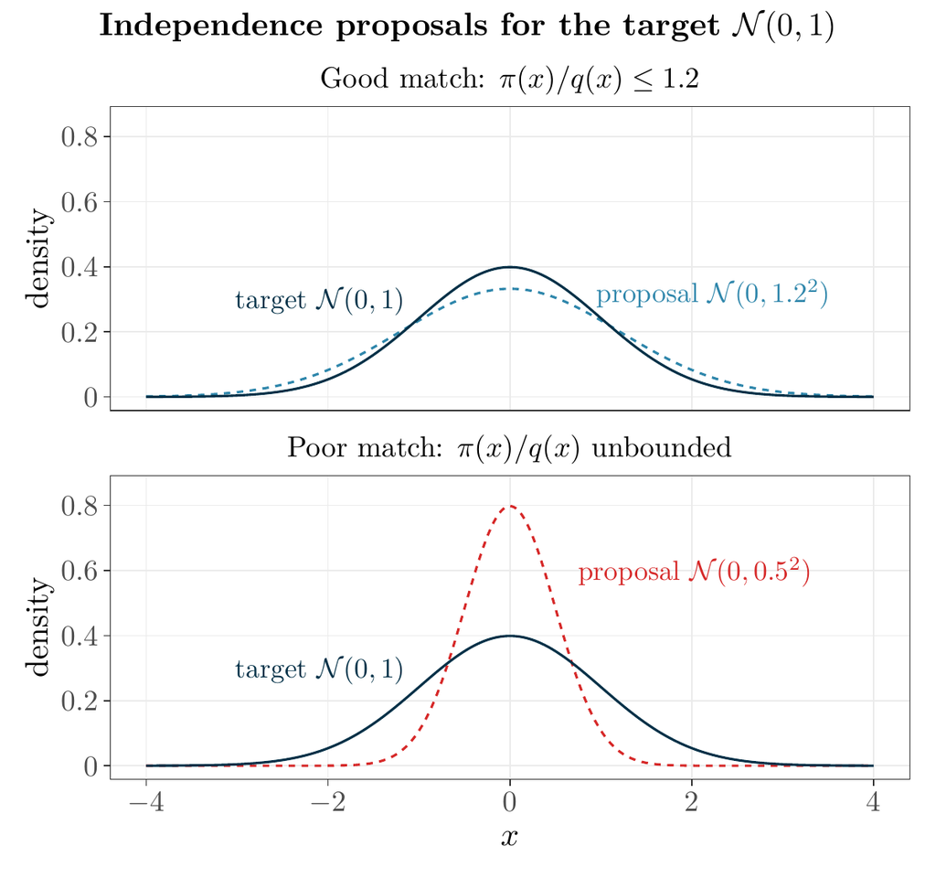

- Top: $q = \Normal(0, 1.2^2)$, with tails heavier than the target’s: $\pi(x)/q(x) \le 1.2$.
- Bottom: $q = \Normal(0, 0.5^2)$, with lighter tails: $\pi(x)/q(x) = 0.5\,e^{1.5x^2}$, unbounded.
- An independence proposal needs tails at least as heavy as the target’s, so that $\pi/q$ stays bounded.

where $\pi$: the target $\Normal(0, 1)$; $q$: the proposal density; $x$: a state.

## Bounded and Unbounded Weights

- Recall the weight $w(x) = \pi(x)/q(x)$ and the acceptance probability $\alpha(x, y) = \min\bigl(1, w(y)/w(x)\bigr)$.
- Bounded weights: if $\pi(x)/q(x) \le M$ for all $x$, the chain is geometrically ergodic with $C(x) = 1$ and $r = 1 - 1/M$. From every start $x$, the total variation distance to $\pi$ after $t$ steps is at most $(1 - 1/M)^t$.
- The proposal $\Normal(0, 1.2^2)$ for the target $\Normal(0, 1)$: $M = 1.2$, so $r = 1 - 1/1.2 = 0.167$.
- Unbounded weights: if $\pi(x)/q(x)$ is unbounded, the chain is not geometrically ergodic (Mengersen and Tweedie, 1996): a state with a large weight can hold it arbitrarily long.
- Recall accept-reject’s $M$ from week 3? What does it bound here?

The same ratio: $f/g \le M$ there, $\pi/q \le M$ here. Where accept-reject can run with this $q$, the independence sampler converges at rate $1 - 1/M$.

where $x$, $y$: the current state and the proposed value; $\pi$, $q$: the target and proposal, normalized densities; $w$: the weight; $\alpha$: the acceptance probability; $M$: a bound on the weight; $C(x)$, $r$: the constant and the rate in the definition of geometric ergodicity; $t$: the number of steps; $f$, $g$: accept-reject’s target and sampling densities.

## Type 3: Log-Scale Proposals

- $Y = x\,e^{Z}$, $Z \sim \Normal(0, s^2)$: then $\log Y \sim \Normal(\log x, s^2)$ and $Y > 0$. Change of variables, with the Jacobian $d\log y/dy = 1/y$, gives its density:

$$q(y \mid x) = \phi(\log y; \log x, s^2)\,\frac{d \log y}{dy} = \frac{\phi(\log y; \log x, s^2)}{y}$$

$$\frac{q(x \mid y)}{q(y \mid x)} = \frac{\phi(\log x; \log y, s^2)/x}{\phi(\log y; \log x, s^2)/y} = \boxed{\frac{y}{x}} \qquad \text{since } \phi(a; b, s^2) = \phi(b; a, s^2)$$

- So $\alpha(x, y) = \min\left(1, \dfrac{\pi(y)}{\pi(x)} \cdot \dfrac{y}{x}\right)$: the Hastings correction is the ratio of the Jacobians at the two points, $(1/x)/(1/y)$.

where $x$: the current state; $Y$, $y$: the proposed value; $Z$: the normal step; $s$: its standard deviation; $\phi(y; m, s^2)$: the normal density with mean $m$ and variance $s^2$, at $y$; $\pi$: the target density; $\alpha(x, y)$: the acceptance probability.

## Log-Scale Proposal for the Gamma Posterior

- Recall the Gamma posterior, $\pi(\lambda \mid \mathbf{x}) \propto \lambda^{218}e^{-50.5\lambda}$ for $\lambda > 0$. Propose $\lambda^* = \lambda^{(t)}e^{Z}$, $Z \sim \Normal(0, s^2)$, and accept with probability

$$\alpha(\lambda^{(t)}, \lambda^*) = \min\left(1, \frac{(\lambda^*)^{218}e^{-50.5\lambda^*}}{(\lambda^{(t)})^{218}e^{-50.5\lambda^{(t)}}} \cdot \frac{\lambda^*}{\lambda^{(t)}}\right)$$

- Every proposal is positive: nothing is rejected for leaving the support.
- At $s = 0.3$: acceptance rate 0.27; ESS about 19% of the 9,000 kept draws.
- Mean of the kept draws 4.343, against the exact 4.337.

where $\lambda$: the Poisson rate; $\mathbf{x}$: the observed counts; $\lambda^{(t)}$: the state at time $t$; $\lambda^*$: the proposed value; $Z$: the normal step; $s$: its standard deviation.

## Example 1: Beta–Binomial

- **Data:** 100 Bernoulli draws simulated with $p = 0.7$: 76 successes.
- **Model:** $X_1, \ldots, X_n \mid p \iid \Ber(p)$, $n = 100$.
- **Prior:** $p \sim \Betad(2, 2)$.
- **Posterior:** $p \mid \mathbf{x} \sim \Betad\bigl(2 + \sum_i x_i,\ 2 + n - \sum_i x_i\bigr) = \Betad(78, 26)$, with mean 0.75.
- Likelihood times prior, the unnormalized posterior:
  $$\pi(p \mid \mathbf{x}) \propto p^{76}(1 - p)^{24} \times p(1 - p) = p^{77}(1 - p)^{25}, \quad 0 < p < 1$$

where $p$: the success probability; $\mathbf{x} = (x_1, \ldots, x_n)$: the observed draws.

## Beta–Binomial: Independence Sampler

- **Proposal:** the prior: $p^* \sim \Betad(2, 2)$, with density $q(p) \propto p(1 - p)$.
- **Acceptance probability:**
  $$\alpha(p^{(t)}, p^*) = \min\left(1, \frac{\pi(p^* \mid \mathbf{x})\,q(p^{(t)})}{\pi(p^{(t)} \mid \mathbf{x})\,q(p^*)}\right) = \min\left(1, \frac{(p^*)^{76}(1 - p^*)^{24}}{(p^{(t)})^{76}(1 - p^{(t)})^{24}}\right)$$
- With the prior as proposal, the weight is $\pi(p \mid \mathbf{x})/q(p) \propto p^{77}(1 - p)^{25}/\bigl(p(1 - p)\bigr) = p^{76}(1 - p)^{24}$, the likelihood up to a constant: we accept on the likelihood ratio.

where $p^{(t)}$: the state at time $t$; $p^*$: the proposed value; $q$: the proposal density; $\pi(p \mid \mathbf{x})$: the posterior.

## Beta–Binomial: Results

- The chain starts at $p^{(0)} = 0.5$; the first 1000 draws are discarded and 9,000 kept.
- Acceptance rate 0.15: most draws from the prior land where the posterior has little density.
- Mean of the kept draws 0.751, against the exact 0.750.
- ESS about 986 of the 9,000 kept draws.

where $p$: the success probability.

## Beta–Binomial: Logit Random Walk

- A random walk on the logit scale: $\operatorname{logit} p^* = \operatorname{logit} p^{(t)} + Z$, $Z \sim \Normal(0, s^2)$, $s = 0.5$.
- The same derivation as on the log scale, with $\dfrac{d\operatorname{logit} p}{dp} = \dfrac1p + \dfrac{1}{1 - p} = \dfrac{1}{p(1 - p)}$:

$$\begin{aligned}
q(p^* \mid p^{(t)}) &= \frac{\phi(\operatorname{logit} p^*; \operatorname{logit} p^{(t)}, s^2)}{p^*(1 - p^*)} \\
\frac{q(p^{(t)} \mid p^*)}{q(p^* \mid p^{(t)})} &= \frac{\phi(\operatorname{logit} p^{(t)}; \operatorname{logit} p^*, s^2)/\bigl(p^{(t)}(1 - p^{(t)})\bigr)}{\phi(\operatorname{logit} p^*; \operatorname{logit} p^{(t)}, s^2)/\bigl(p^*(1 - p^*)\bigr)} = \frac{p^*(1 - p^*)}{p^{(t)}(1 - p^{(t)})}
\end{aligned}$$

where $p^{(t)}$, $p^*$: the current and proposed values of $p$; $\operatorname{logit} p = \log\bigl(p/(1 - p)\bigr)$; $Z$: the normal step; $s$: its standard deviation; $\phi(y; m, s^2)$: the normal density with mean $m$ and variance $s^2$, at $y$; $q$: the proposal density.

## Beta–Binomial: Comparison of Proposals

Recall the posterior, $\pi(p \mid \mathbf{x}) \propto p^{77}(1 - p)^{25}$, which is $\Betad(78, 26)$ with mean 0.750.

| Proposal | Acceptance rate | Mean of the draws | ESS of 9,000 |
| --- | --- | --- | --- |
| independence, prior $\Betad(2, 2)$ | 0.15 | 0.751 | 986 |
| independence, $\Betad(7, 3)$ | 0.36 | 0.751 | 2,350 |
| logit random walk, $s = 0.5$ | 0.46 | 0.750 | 2,021 |

- The prior proposal has the lowest acceptance rate and ESS: mean 0.50 and SD 0.224, against the posterior’s 0.75 and 0.042.
- $\Betad(7, 3)$, mean 0.70 and SD 0.138, is closer: in this run its ESS is 2.4 times the prior proposal’s.
- The logit random walk needs no global guess: in this run its ESS is 2.0 times the prior proposal’s.
- **The role of the proposal:** every mean is within 0.001 of the exact 0.750; the proposal decides the ESS.

where $p$: the success probability; $\mathbf{x}$: the observed draws; $s$: the standard deviation of the logit step; SD: standard deviation; ESS: the effective sample size.

## Example 2: Logistic Regression

- **Model:** $Y_i \mid x_i \sim \Ber(p_i)$, independent, with $\log\dfrac{p_i}{1 - p_i} = \beta_0 + \beta_1 x_i$.
- **Prior:** $\beta_0, \beta_1$ independent $\Normal(0, \sigma_\beta^2)$, with $\sigma_\beta = 10$.
- **Posterior:** no closed form, known up to a constant:

$$\pi(\beta_0, \beta_1 \mid \mathbf{y}, \mathbf{x}) \propto \prod_{i=1}^n p_i^{y_i}(1 - p_i)^{1 - y_i} \times \prod_{j=0}^1 \exp\left(-\frac{\beta_j^2}{2\sigma_\beta^2}\right)$$

where $Y_i$, $y_i$: the binary outcome of case $i$, not a proposed value; $x_i$: its predictor; $p_i$: its success probability; $\beta_0$, $\beta_1$: the intercept and the slope; $\sigma_\beta$: the prior standard deviation; $\mathbf{y}$, $\mathbf{x}$: all $n$ outcomes and predictors.

## Logistic Regression: Data

- $n = 200$ simulated pairs $(x_i, y_i)$: $x_i \iid \Normal(0, 1)$, and $y_i$ drawn from the model at $\beta_0 = -0.5$, $\beta_1 = 1.5$.
- The outcomes: 79 ones and 121 zeros.
- **The task:** the joint posterior of $(\beta_0, \beta_1)$, checked against the true values and the MLE.

where $x_i$: the predictor; $y_i$: the outcome; $\beta_0$, $\beta_1$: the intercept and the slope.

## Logistic Regression: Posterior

$$y_i\log p_i + (1 - y_i)\log(1 - p_i) = y_i\log\frac{p_i}{1 - p_i} + \log(1 - p_i) = y_i\eta_i - \log(1 + e^{\eta_i})$$

$$\log\pi(\beta_0, \beta_1 \mid \mathbf{y}, \mathbf{x}) = \sum_{i=1}^n \bigl[y_i\eta_i - \log(1 + e^{\eta_i})\bigr] - \frac{\beta_0^2 + \beta_1^2}{2\sigma_\beta^2} + \text{constant}$$

```r
log_posterior_logistic <- function(beta, Y, X, sigma_beta = 10) {
  beta0 <- beta[1]
  beta1 <- beta[2]
  eta <- beta0 + beta1 * X                                   # linear predictor
  log_lik <- sum(Y * eta - log(1 + exp(eta)))                # log-likelihood
  log_prior <- sum(dnorm(beta, 0, sigma_beta, log = TRUE))   # log-prior
  log_lik + log_prior
}
```

where $\eta_i = \beta_0 + \beta_1 x_i = \log\bigl(p_i/(1 - p_i)\bigr)$: the linear predictor, so $1 - p_i = 1/(1 + e^{\eta_i})$; $y_i$, $x_i$: outcome and predictor of case $i$; $\mathbf{y}$, $\mathbf{x}$: all $n$ of them; `Y`, `X`: the same in code, not a proposed value; $\sigma_\beta$: the prior standard deviation.

## Logistic Regression: M-H Implementation

```r
mh_logistic <- function(n_iter, proposal_cov) {
  beta <- matrix(0, nrow = n_iter, ncol = 2)
  beta[1, ] <- c(0, 0)                                       # initialize
  n_accept <- 0
  for (t in 2:n_iter) {
    beta_star <- beta[t - 1, ] + MASS::mvrnorm(1, mu = c(0, 0), Sigma = proposal_cov)
    log_alpha <- log_posterior_logistic(beta_star, Y, X) -
                 log_posterior_logistic(beta[t - 1, ], Y, X)
    if (log(runif(1)) < log_alpha) {
      beta[t, ] <- beta_star; n_accept <- n_accept + 1
    } else beta[t, ] <- beta[t - 1, ]
  }
  list(beta = beta, accept_rate = n_accept / n_iter)
}
```

where `beta_star`: the proposed value, a symmetric random walk step, so `log_alpha` has no $q$ terms; `Y`, `X`: the outcomes and predictors; `proposal_cov`: the covariance of the step, $0.1\,\mathbf{I}$ here, with $\mathbf{I}$ the identity matrix.

## Logistic Regression: Results

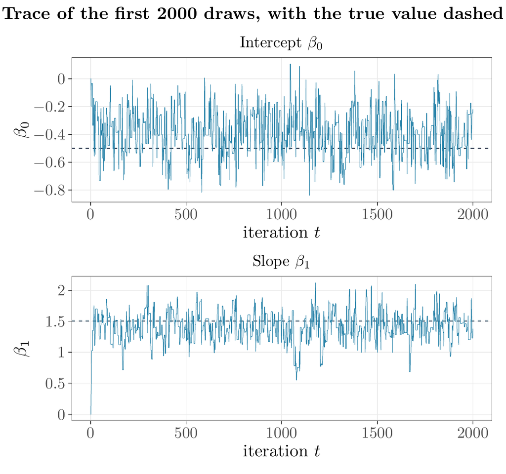

- Top: trace of the intercept $\beta_0$; dashed: its true value, $-0.5$.
- Bottom: trace of the slope $\beta_1$; dashed: its true value, $1.5$.
- Acceptance rate 0.37; ESS about 2,390 and 1,540 of the 15,000 draws kept after 5000.
- Both traces leave the start, $(0, 0)$, quickly and then fluctuate around a stable level.

where $\beta_0$, $\beta_1$: the intercept and the slope.

## Logistic Regression: Posterior Distributions

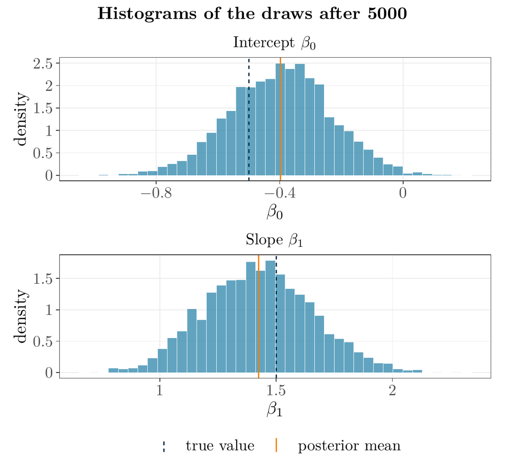

- Top: histogram of the draws of $\beta_0$ after 5000.
- Bottom: the same for $\beta_1$.
- Dashed: the true value. Solid orange: the posterior mean.
- Posterior means $-0.398$ and $1.424$; true values $-0.5$ and $1.5$.

where $\beta_0$, $\beta_1$: the intercept and the slope.

## Logistic Regression: Posterior Summaries

| Parameter | Truth | Posterior mean | Posterior SD | 2.5% quantile | 97.5% quantile | ESS |
| --- | --- | --- | --- | --- | --- | --- |
| $\beta_0$ | $-0.5$ | $-0.398$ | $0.164$ | $-0.725$ | $-0.077$ | 2,386 |
| $\beta_1$ | $1.5$ | $1.424$ | $0.232$ | $0.991$ | $1.890$ | 1,539 |

- On this dataset, the 95% credible intervals contain the true values.
- Given the data, each parameter lies in its exact 95% credible interval with probability 0.95. The table estimates that interval’s ends from the draws.
- Monte Carlo standard errors of the posterior means: 0.003 and 0.006.

where $\beta_0$, $\beta_1$: the intercept and the slope; 2.5% and 97.5% quantile: the ends of the 95% credible interval; SD: standard deviation; ESS: the effective sample size, of 15,000 kept draws.

## Joint Posterior

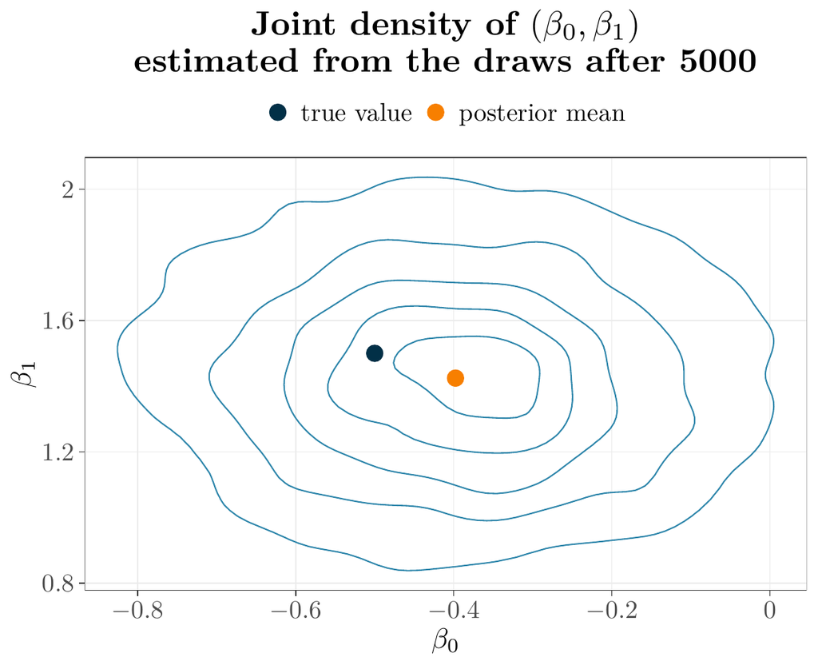

- Contours: the joint density of $(\beta_0, \beta_1)$, estimated from the draws after 5000.
- Points: the true value and the posterior mean.
- On this dataset the posterior correlation of $\beta_0$ and $\beta_1$ is $-0.06$, over 15,000 kept draws.
- With a correlation this small, a proposal with independent coordinates loses little.

where $\beta_0$, $\beta_1$: the intercept and the slope.

## Comparison: MLE vs Bayesian

| Parameter | Truth | MLE | MLE SE | Posterior mean | Posterior SD |
| --- | --- | --- | --- | --- | --- |
| $\beta_0$ | $-0.5$ | $-0.399$ | $0.165$ | $-0.398$ | $0.164$ |
| $\beta_1$ | $1.5$ | $1.398$ | $0.238$ | $1.424$ | $0.232$ |

- With a weak prior ($\sigma_\beta = 10$), the exact posterior means are within about 0.03 of the MLEs.
- The exact posterior standard deviations are within about 0.003 of the MLE standard errors.
- The table’s posterior columns are MCMC estimates: they differ from the exact values by Monte Carlo error.

where $\beta_0$, $\beta_1$: the intercept and the slope; MLE: the maximum likelihood estimate from `glm()`; SE, SD: standard error, standard deviation; $\sigma_\beta$: the prior standard deviation; the two distances are for the exact posterior, by quadrature.

## Type 4: Langevin Proposal (Preview)

$$Y = x + \frac{\epsilon^2}{2}\,\nabla\log\pi(x) + \epsilon Z, \quad Z \sim \Normal(\mathbf{0}, \mathbf{I})$$

- Incorporates gradient information: drift toward high-density regions (the gradient) plus random noise.
- Proposal density:
  $$q(y \mid x) = \phi\Bigl(y;\ x + \frac{\epsilon^2}{2}\,\nabla\log\pi(x),\ \epsilon^2\mathbf{I}\Bigr)$$
- Asymmetric: from each point the proposal drifts uphill, so $q(y \mid x) \ne q(x \mid y)$ in general, and the full M-H correction is needed.

where $x \in \R^d$: the current state; $Y$, $y$: the proposed value; $\epsilon$: the step size; $\nabla\log\pi(x)$: the gradient of the log target; $Z$: the noise; $\mathbf{0}$, $\mathbf{I}$: the zero vector, the identity matrix; $\phi(y; \mathbf{m}, \mathbf{S})$: the normal density with mean $\mathbf{m}$, covariance $\mathbf{S}$.

## Langevin: Bridge to Hamiltonian MC

**Langevin**

- Uses the first-order gradient
- Single proposal step
- Requires the M-H correction
- The noise is the move: one step of size about $\epsilon$

**Hamiltonian MC**

- Uses the gradient for deterministic dynamics
- Multiple integration steps
- Corrected by a Metropolis step
- The noise sets the momentum; the integration steps carry the chain far

## Proposal Design Principles

- **Support matching:** every set with $\pi(A) > 0$ must be reachable from every start: do not get trapped in subsets.
- **Scale matching:** proposal spread should match target spread: too narrow gives slow mixing, too wide gives high rejection.
- **Shape matching:** for elongated posteriors, give the proposal the target’s correlation structure: use multivariate proposals in place of componentwise ones.
- **Adaptation:** learn the proposal during burn-in, then freeze it: a proposal that keeps changing with the chain’s history makes the chain non-Markov, and $\pi$ need not stay stationary.

where $A$: a set of states; $\pi(A)$: the probability the target gives $A$.

## Common Proposal Strategies

| Proposal Type | When to Use | Pros | Cons |
| --- | --- | --- | --- |
| Random walk | General purpose | Simple; no $q$ terms in the ratio | Can be slow |
| Independence | Close to posterior, with $\pi/q$ bounded | Low autocorrelation when the match is good | Needs a good guess: with $\pi/q$ unbounded it can stick |
| Langevin | Smooth target | Uses gradient information | Needs derivatives |
| Adaptive | Complex geometry | Learns the proposal from the chain | Freeze it after burn-in |

where $\pi$: the target density; $q$: the proposal density.

## Sufficient Conditions for Convergence

- Recall the Fundamental Theorem from last week? For an M-H chain with target $\pi$ that proposes the whole state from one density:
- **Irreducibility:** from every start with $\pi(x) > 0$ the chain can reach every set of positive probability.
- **Aperiodicity:** the chain does not cycle through disjoint regions.
- **Detailed balance:** satisfied by construction, so $\pi$ is stationary.

If these hold, then (Tierney, 1994), for every set $A$ and every start $x$ with $\pi(x) > 0$,

$$P(X_t \in A \mid X_0 = x) \to \pi(A) \quad \text{as } t \to \infty$$

- From any start in the support, the distribution of $X_t$ approaches $\pi$. The statement is a limit: it gives no rate.

where $X_t$: the state at time $t$; $A$: a set of states; $\pi(A)$: the probability $\pi$ gives $A$.

## Practical Considerations

- **Componentwise updates:** one coordinate at a time, each with its own accept-or-reject step.
- **Joint updates:** all coordinates at once, with a multivariate $q(y \mid x)$.
- **Block updates:** a hybrid, one group of coordinates at a time.
- Higher acceptance is no guarantee of a higher ESS, the count of independent draws the chain is worth: recall the Gamma random walk, $\lambda^* = \lambda^{(t)} + Z$, $Z \sim \Normal(0, s^2)$, which at $s = 0.01$ had acceptance rate 0.99 and ESS about 19, a rough estimate at this stickiness.
- Always work on the log scale, check for numerical issues, and monitor acceptance rates per component.

where $x$, $y$: the current and proposed values, here vectors; $q(y \mid x)$: the proposal density from $x$ to $y$; $\lambda^{(t)}$, $\lambda^*$: the current and proposed Poisson rates; $Z$: the normal step; $s$: its standard deviation; ESS: the effective sample size.

## Normalizing Constants

M-H only needs ratios:

$$\alpha(x, y) = \min\left(1, \frac{\pi(y)/q(y \mid x)}{\pi(x)/q(x \mid y)}\right)$$

- If $\pi(x) = c\,\tilde\pi(x)$, the $c$ cancels.
- A posterior has this form, with $c = 1/m(\mathbf{x})$, so we never need $m(\mathbf{x})$:
  $$\pi(\theta \mid \mathbf{x}) = \frac{L(\theta)\,\pi_0(\theta)}{m(\mathbf{x})}, \qquad m(\mathbf{x}) = \int L(\theta)\,\pi_0(\theta)\,d\theta$$

where $x$, $y$: the current and proposed states; $\tilde\pi$: the target up to the constant $c$; $q(y \mid x)$: the proposal density from $x$ to $y$; $\theta$: the unknown; $\mathbf{x}$: the data; $L(\theta)$: the likelihood; $\pi_0(\theta)$: the prior density; $m(\mathbf{x})$: the normalizing constant.

## Proposal Shapes

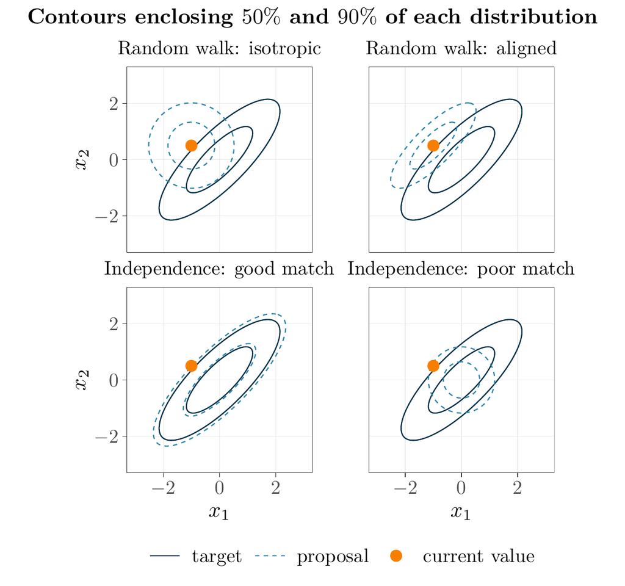

- Top left: random walk, covariance $0.5\,\mathbf{I}$: ignores the target’s shape.
- Top right: random walk, covariance $0.5\,\boldsymbol\Sigma$: the target’s shape.
- Bottom left: independence, $\Normal(\mathbf{0}, 1.2\,\boldsymbol\Sigma)$: $\pi/q \le 1.2$.
- Bottom right: independence, $\Normal(\mathbf{0}, 0.3\,\mathbf{I})$: $\pi/q$ unbounded along the target’s long axis.
- Match the proposal’s scale and shape to the target’s.

where $x_1$, $x_2$: the coordinates; $\boldsymbol\Sigma$: the target’s covariance, unit variances and correlation 0.8; $\mathbf{I}$: the identity matrix; $\pi$, $q$: the target and proposal densities.

## Types of M-H

| Type | Proposal | $q(x \mid y)/q(y \mid x)$ | Character |
| --- | --- | --- | --- |
| Random walk | $Y = x + Z$, $Z \sim g$ symmetric | $1$ | symmetric, local exploration; reduces to Metropolis |
| Independence | $Y \sim q$ | $q(x)/q(y)$ | global proposals; like importance sampling with a correction |
| Log-scale | $Y = x\,e^{Z}$, $Z \sim \Normal(0, s^2)$ | $y/x$ | a positive parameter; the correction is a ratio of Jacobians |
| Langevin | $Y = x + \frac{\epsilon^2}{2}\nabla\log\pi(x) + \epsilon Z$ | a ratio of normal densities | uses gradient information; bridge to Hamiltonian MC |

where $x$: the current state; $y$, $Y$: the proposed value; $Z$: the step or noise; $g$: a symmetric density; $s$: a standard deviation; $\epsilon$: the step size; $q$: the proposal density.

## Notation

| Symbol | Meaning |
| --- | --- |
| $X_t$, $Y$, $N$ | state, proposed value, chain length |
| $\pi$, $\tilde\pi$, $\pi_0$ | target; target up to a constant; prior density |
| $q(y \mid x)$ | proposal density from $x$ to $y$ |
| $\alpha(x, y)$, $R(x, y)$ | acceptance probability, Hastings ratio |
| $K(x, y)$, $r_{\text{rej}}(x)$ | transition density, rejection probability |
| $Z$, $\ell$, $s$ | a step; half-width of a uniform one; SD of a normal one |

| Symbol | Meaning |
| --- | --- |
| $w(x)$, $M$ | importance weight $\pi(x)/q(x)$, a bound on it |
| $C(x)$, $r$ | geometric constant, rate |
| $\phi(y; m, s^2)$ | $\Normal(m, s^2)$ density at $y$ |
| $\epsilon$ | Langevin step size |
| $\bar h_N$, $\sigma_h^2$ | average of $h$ over the chain, $\Var_\pi(h(X))$ |
| $\kappa$, ESS | $1 + 2\sum_{k \ge 1}\rho_k$, $N/\kappa$ |
| $L(\theta)$, $m(\mathbf{x})$ | likelihood, normalizing constant |

## Punchlines, and What Comes Next

- Tuning aims at a large ESS, through weak dependence between successive draws: on the Gamma posterior, acceptance rates 0.99, 0.44, 0.05 gave ESS about 19 (rough), 10,900, 1,770 of 49,000 kept draws.
- Without a correction an asymmetric proposal breaks detailed balance, and nothing keeps $\pi$ stationary.
- The Hastings correction enables asymmetric proposals: $\alpha(x, y) = \min\bigl(1, R(x, y)\bigr)$ is the largest solution of detailed balance.
- Different proposals suit different problems: random walk for general purpose, independence when $\pi/q$ is bounded, log-scale for a positive parameter, Langevin when you can compute gradients.
- We still only need unnormalized densities: normalizing constants cancel in the ratio.

Every sampler we ran is a proposal and a ratio. Hastings tells us which ratio keeps $\pi$ stationary, for any proposal. What is left is choosing the proposal, and the ESS is how we judge the choice.

Next: tuning a proposal in practice, and Gibbs sampling, which proposes from the full conditional distribution of one coordinate given the others and accepts every time.